# Import, export and local transmission

The input for this analysis is the results from the maximum likelihood mapping of the geographical states on the full phylogenetic tree of the 9732 genomes.

## Import versus local transmission for Norway, Australia, Europe and the USA

From the mapped geographical lineage distributions we can derive the number of importation and local transmission events for each location (based on the available sequences). NB. we do not account for unobserved infections (sequences), and hence the estimated number only reflects the fraction of *sequenced* genomes that is assigned to specific lineages. The relative growth between the lineages (growth of an transmission lineage implies local transmission), is an important quantity and tells us how dominant specific lineages have become over time. This too could be affected by nonrandom sampling such as targeted sampling of lineages with anitibiotic resistance.

## Cumulative growth of transmission lineages

The following plots show the cumulative number of sequences obtained from each estimated transmission lineage over time

### Norway

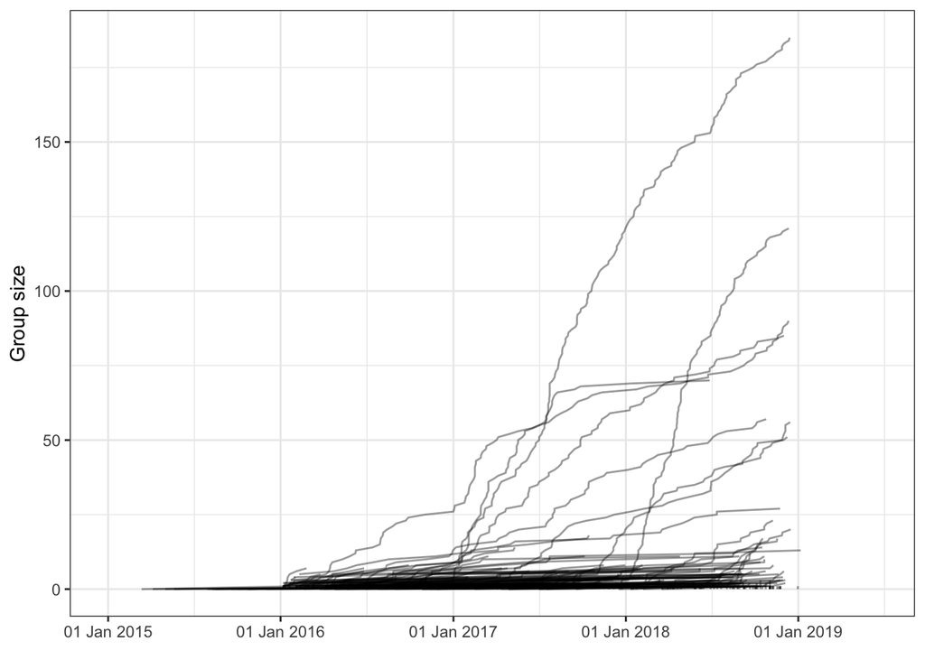

```r
name_date_NOR = name_date[name_date$name%in%nor_tips,]
linfo_NOR = lineage_info(Result_NOR,name_date = name_date_NOR)
LineageHomology::lineage_growth_cumulative(linfo_NOR,datelims=c("2015-01-01","2019-06-15","1 year"))
```

### Australia

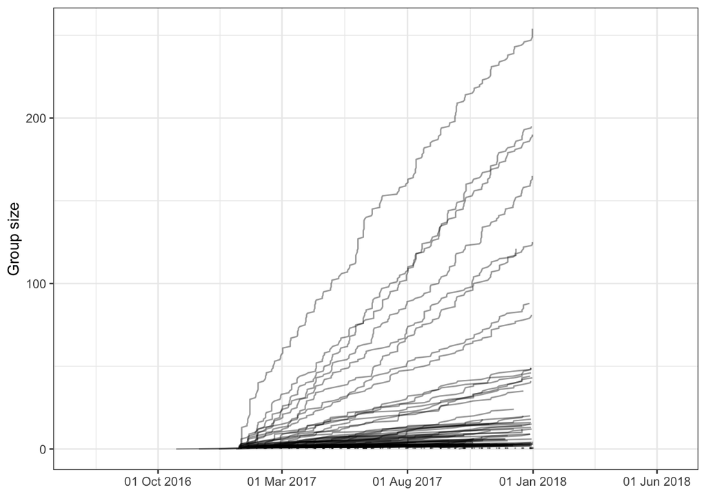

```r
name_date_AUS = name_date[name_date$name%in%aus_tips,]
linfo_AUS = lineage_info(Result_AUS,name_date = name_date_AUS)
LineageHomology::lineage_growth_cumulative(linfo_AUS,datelims=c("2016-07-01","2018-06-15","5 months"))
```

### The USA

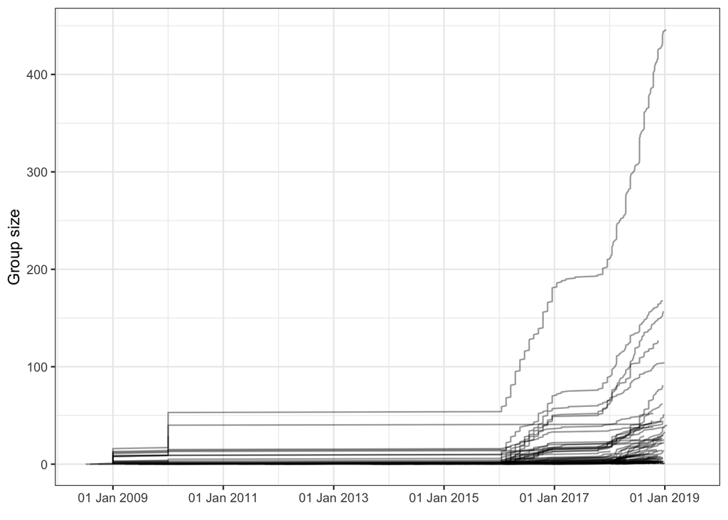

```r
name_date_USA = name_date[name_date$name%in%usa_tips,]
linfo_USA = lineage_info(Result_USA,name_date = name_date_USA)
LineageHomology::lineage_growth_cumulative(linfo_USA,datelims=c("2008-07-01","2019-06-15","2 year"))
```

### Europe

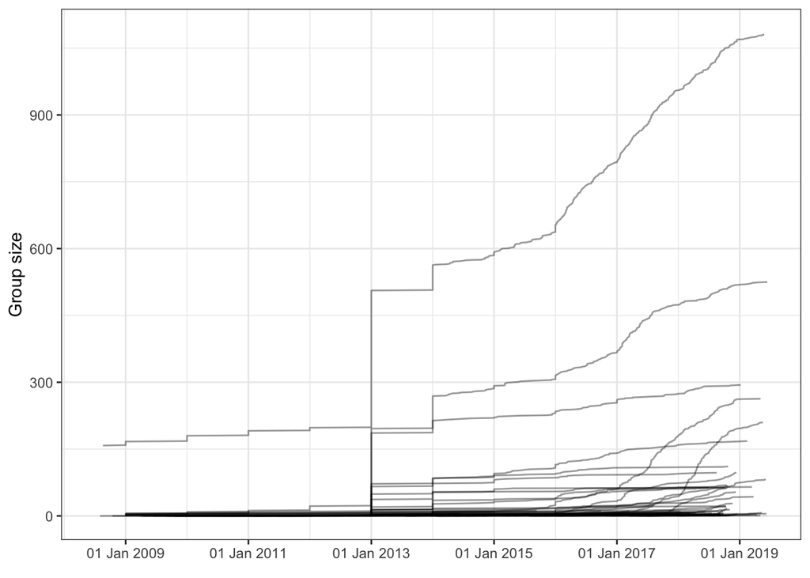

```r
name_date_EUR = name_date[name_date$name%in%eur_tips,]
linfo_EUR = lineage_info(Result_EUR,name_date = name_date_EUR)
LineageHomology::lineage_growth_cumulative(linfo_EUR,datelims=c("2008-07-01","2019-06-15","2 year"))
```

## Aggregated estimates of import, local transmission and export over the full phylogeny:

```r
c1 = Summarize_import_export_local_transmission(implocexp_NOR); round(c1,4)
```

```
##                                2.5%       50%     97.5%
## Import                     706.8500  736.0000  764.0000
## Local transmission        1929.4250 1967.5000 2004.0500
## Export                     922.4750  980.5000 1028.0000
## Local explained by import    0.2649    0.2705    0.2759
## Exports per local case       0.1955    0.2165    0.2320
```

```r
c2 = Summarize_import_export_local_transmission(implocexp_AUS); round(c2,4)
```

```
##                                2.5%       50%     97.5%
## Import                     356.4750  371.5000  391.0000
## Local transmission        2152.0000 2175.0000 2199.0500
## Export                     312.4750  346.0000  381.6750
## Local explained by import    0.1243    0.1268    0.1295
## Exports per local case       0.0576    0.0654    0.0720
```

```r
c3 = Summarize_import_export_local_transmission(implocexp_USA); round(c3,4)
```

```
##                                2.5%       50%    97.5%
## Import                     370.9500  390.0000  407.575
## Local transmission        2574.3750 2595.5000 2620.100
## Export                     586.9000  617.0000  645.000
## Local explained by import    0.1206    0.1237    0.127
## Exports per local case       0.1607    0.1706    0.178
```

```r
c4 = Summarize_import_export_local_transmission(implocexp_EUR); round(c4,4)
```

```
##                                2.5%       50%     97.5%
## Import                     449.4750  476.0000  499.5250
## Local transmission        4233.9500 4266.5000 4306.0000
## Export                     620.0000  643.5000  662.0000
## Local explained by import    0.1106    0.1161    0.1206
## Exports per local case       0.1526    0.1570    0.1598
```

## Stratifying the estimates on the periods 2010-2014, 2014-2018, and 2010-2018 (total), we obtain the following estimates

### Norway and Australia

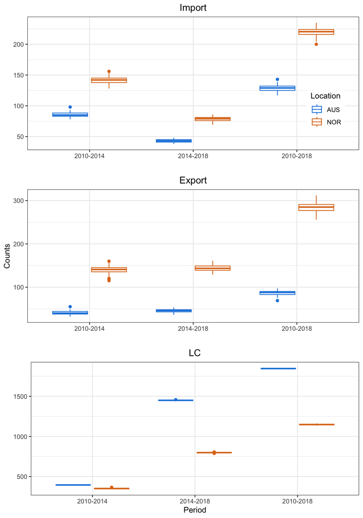

### Europe and USA

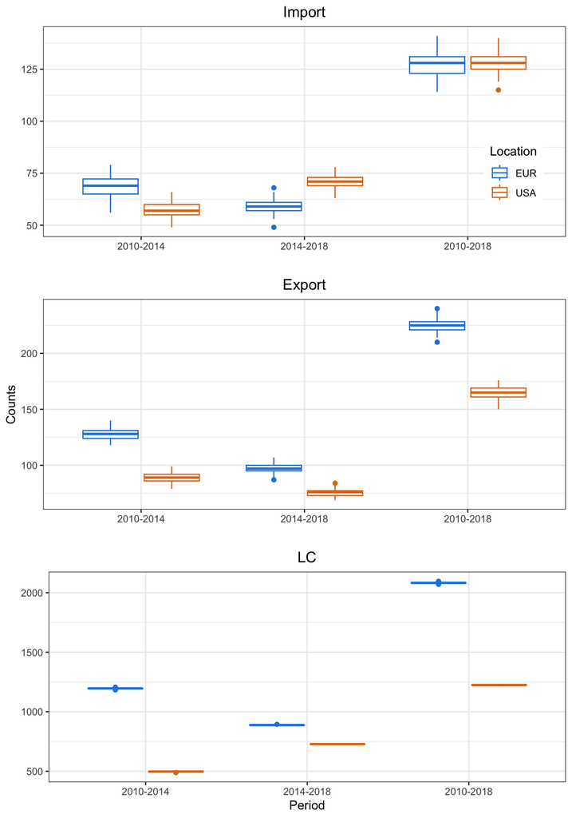

## Fraction of cases that can be explained by importation in respective locations

By dividing importation and exportation by (import + local transmission - export) respectively, we obtain the following estimates of the number of cases in the given locations that can be explained by importation.

### Norway and Australia

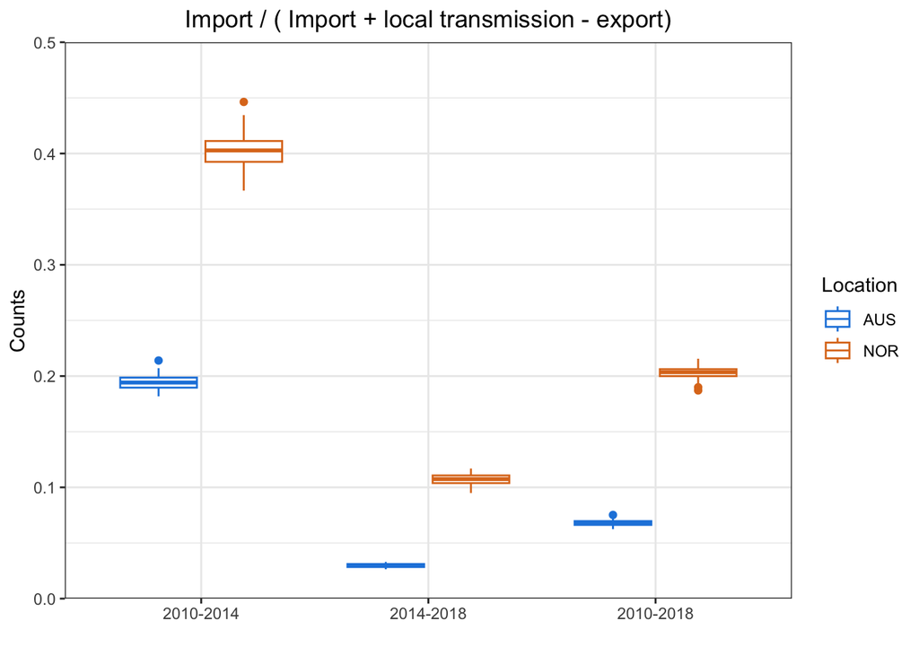

### Europe and the USA

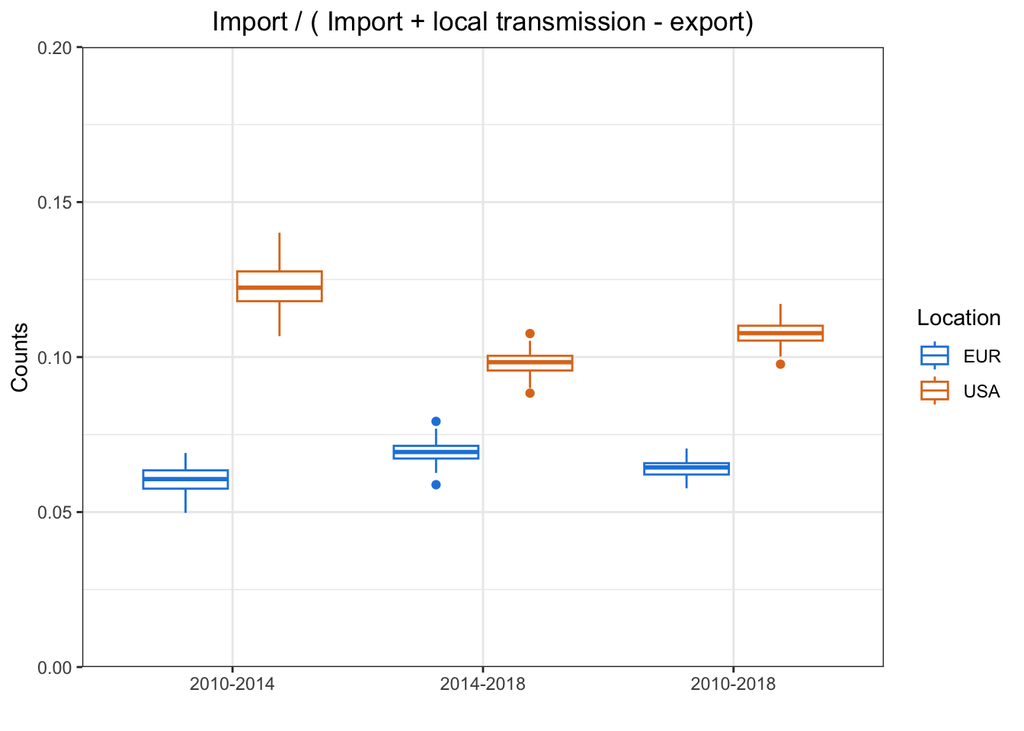

## Fraction of total events that are imports, exports and local transmissions in the period 2000-2018.

### Norway

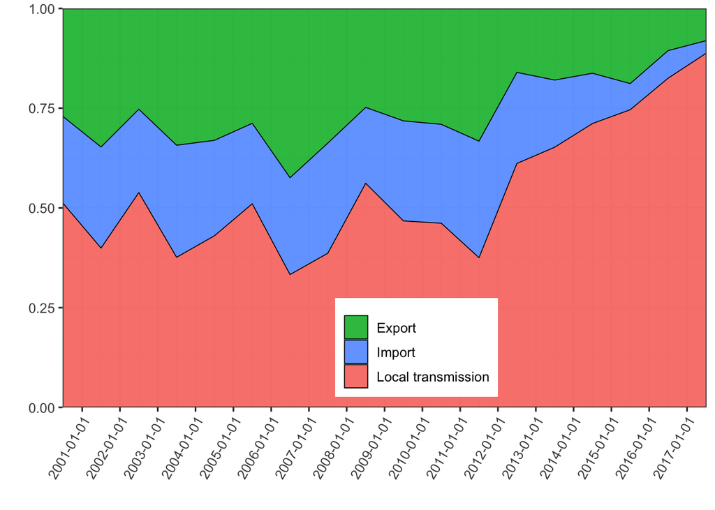

### Australia

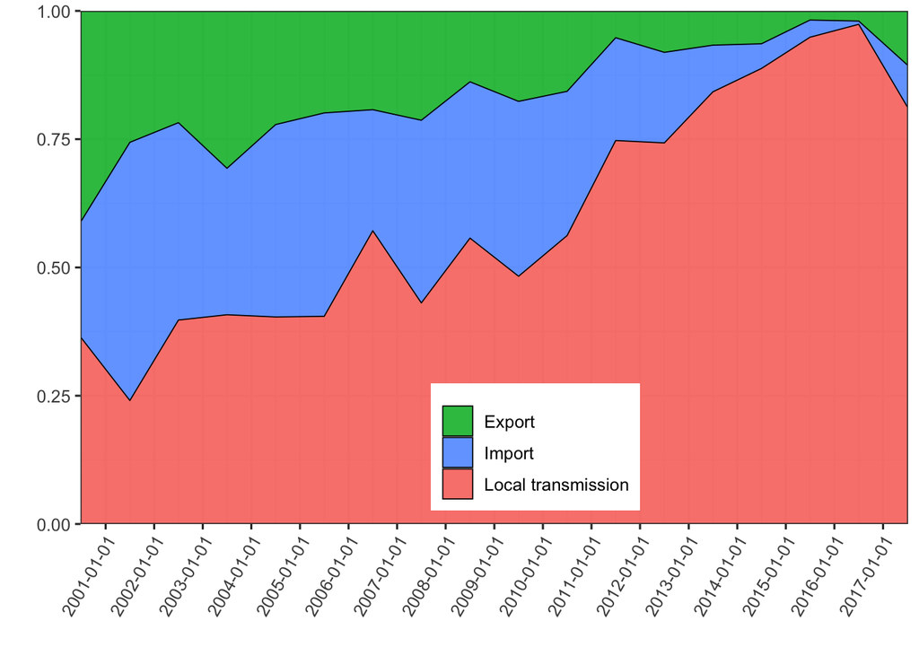

### USA

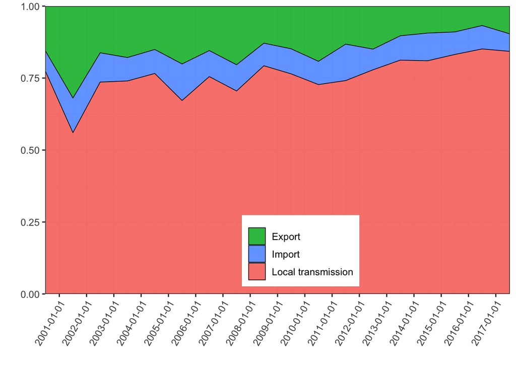

### Europe

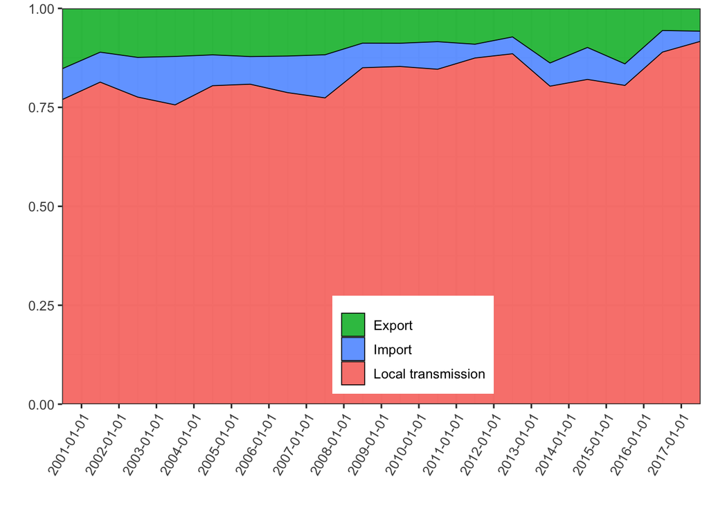

## Absolute estimates of imports, exports and local transmission in the period 2000-2018.

### Norway

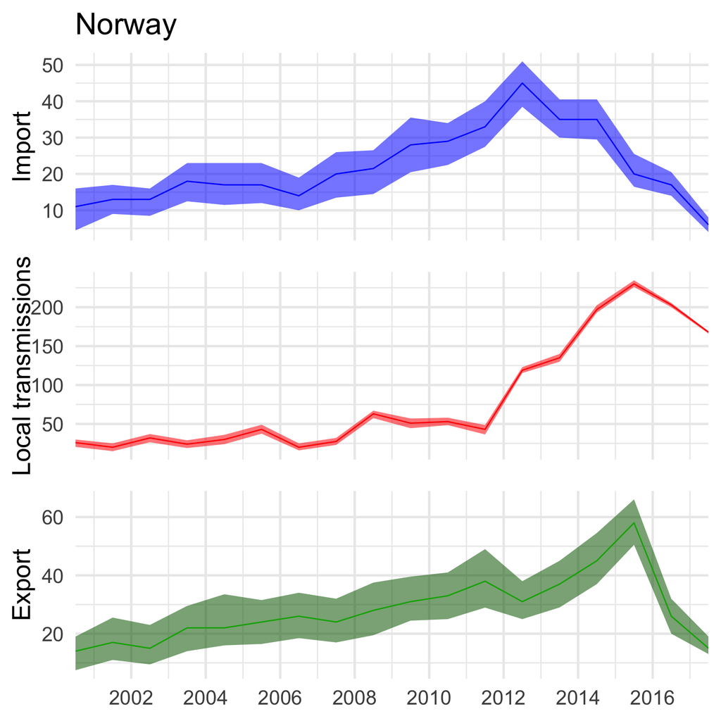

### Australia

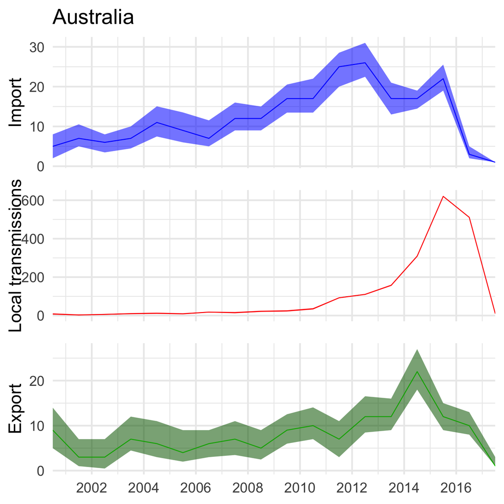

### The USA

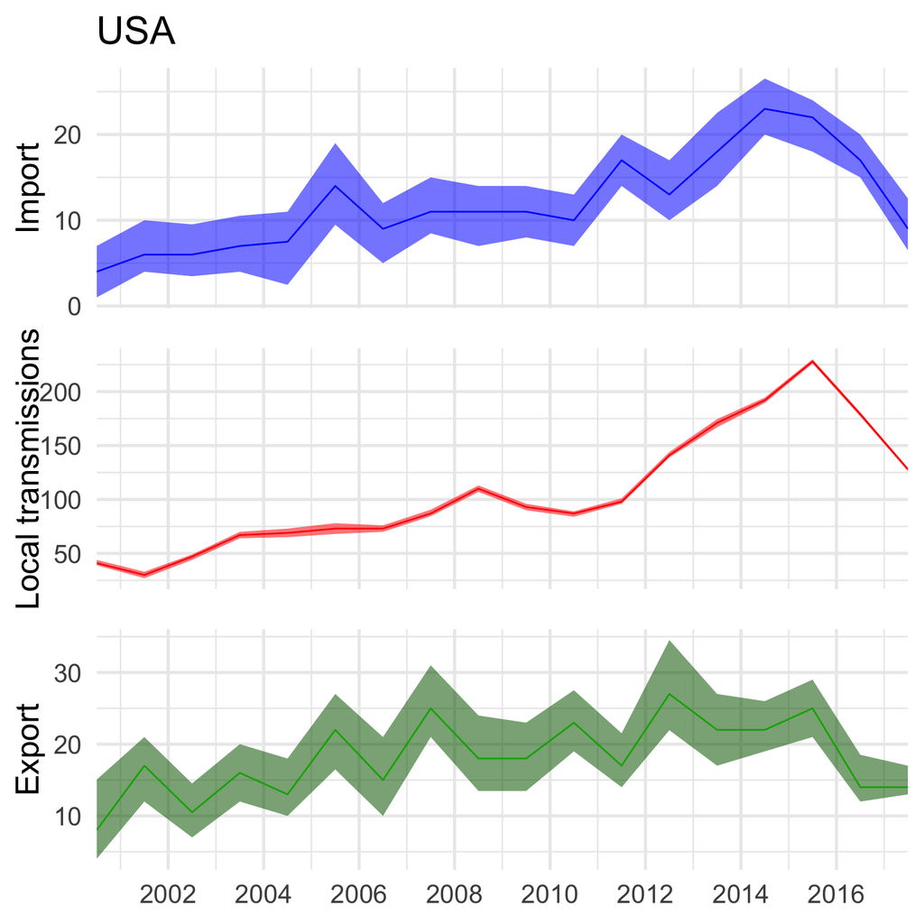

### Europe

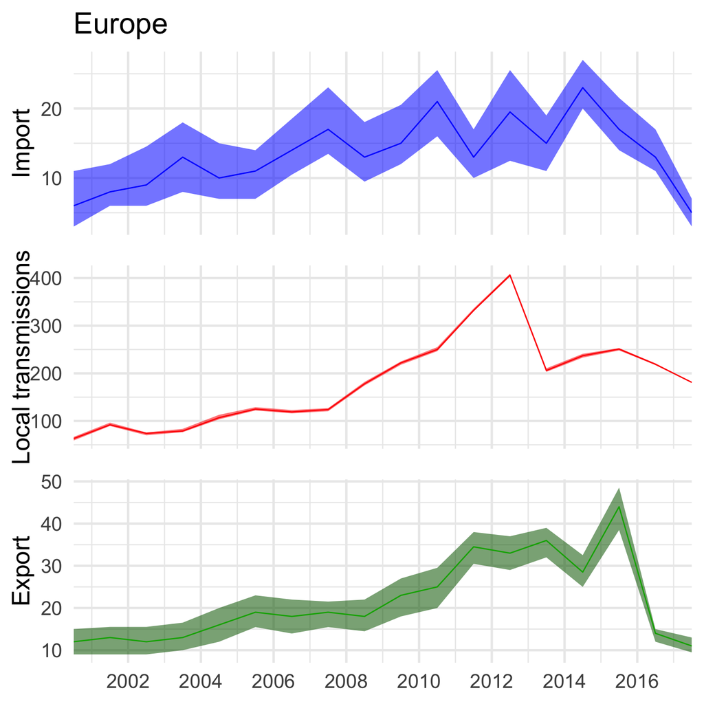